# Final Project for DATA 608

by Thomas Hill

# Final Project: New York State Maternity and Labor Statistics

## Introduction

Pregnancy and childbirth are a critical period for both mother and child. Currently, the most common place of birth remains at a healthcare facility, whether at a birth center or labor and delivery department within a hospital. To help expectant patients and their families make informed decisions about pre-booking a delivery, the state of New York mandates that each facility of a certain size must provide annual aggregate statistics to better inform the decision.

The provided statistics at a minimum must include several maternity-related procedures, including rate of cesarean sections versus vaginal deliveries, breech births delivered vaginally, and deliveries by midwives, as well as elements of medical care such as deliveries using forceps and rates of analgesia/anesthesia, episiotomies, and induction/augmentation of labor. The NY Department of Health adds the caveat that these statistics do not inform about a specific healthcare practitioner’s preferences, but are useful in playing an active part in planning for childbirth.

```
##  [1] "Year"            "Facility.ID"     "Hospital.Name"   "Hospital.County"
##  [5] "Measure.ID"      "Measure.Name"    "Denominator"     "Category"
##  [9] "Count"           "Percent"
```

```
##  [1] 2010 2012 2008 2009 2015 2014 2011 2013 2016 2017
```

```
## [1] 146
```

```
##  [1] "ERIE"          "OSWEGO"        "WARREN"        "ALBANY"
##  [5] "ALLEGANY"      "BROOME"        "CAYUGA"        "CATTARAUGUS"
##  [9] "CHAUTAUQUA"    "CHEMUNG"       "CHENANGO"      "ONONDAGA"
## [13] "CLINTON"       "COLUMBIA"      "CORTLAND"      "DUTCHESS"
## [17] "SUFFOLK"       "FRANKLIN"      "FULTON"        "GENESEE"
## [21] "JEFFERSON"     "LEWIS"         "LIVINGSTON"    "BRONX"
## [25] "MADISON"       "MONROE"        "MONTGOMERY"    "NEW YORK"
## [29] "NASSAU"        "NIAGARA"       "ONEIDA"        "ONTARIO"
## [33] "ORANGE"        "RENSSELAER"    "ORLEANS"       "OTSEGO"
## [37] "PUTNAM"        "ROCKLAND"      "ST LAWRENCE"   "SARATOGA"
## [41] "SCHENECTADY"   "SCHUYLER"      "STEUBEN"       "SULLIVAN"
## [45] "ULSTER"        "TOMPKINS"      "WAYNE"         "WESTCHESTER"
## [49] "WYOMING"       "KINGS"         "QUEENS"        "RICHMOND"
## [53] "Statewide"     "Rest of State"
```

The dataset available for NY state offers the required statistics for a period 2008 – 2017, separated by each hospital and its location. It includes 146 hospitals spread throughout about 80% of New York’s 63 counties. There are two columns for ‘Rest of State’ and ‘Statewide’ that need to be omitted for generating county statistics. The law in question specifies that reporting is mandatory for each facility performing more than 200 deliveries per year, which we can verify.

## Birth Rate by Hospital

```
## # A tibble: 6 x 6
## # Groups:   Year, Hospital.Name [6]
##    Year Hospital.Name          Hospital.County Count annual_hospital_~ above_200
##   <int> <chr>                  <chr>           <int>             <int> <lgl>
## 1  2008 Westfield Memorial Ho~ CHAUTAUQUA         73                73 FALSE
## 2  2011 Medina Memorial Hospi~ ORLEANS            76                76 FALSE
## 3  2009 Eastern Niagara Hospi~ NIAGARA            86                86 FALSE
## 4  2008 Eastern Niagara Hospi~ NIAGARA            91                91 FALSE
## 5  2012 Edward John Noble Hos~ ST LAWRENCE        92                92 FALSE
## 6  2009 Benedictine Hospital   ULSTER            100               100 FALSE
```

```
## [1] 96.4
```

```
## [1] 0.2
```

Looking at the lowest years, it appears that the minimum reports sometimes is lower than 200. These cases represent less than 5% of total hospital reports and 0.2% of the number of births. One plausible explanation for these exceptions are hospitals no longer offering perinatal services.

## Hospitals by County, Region, and Borough

### County

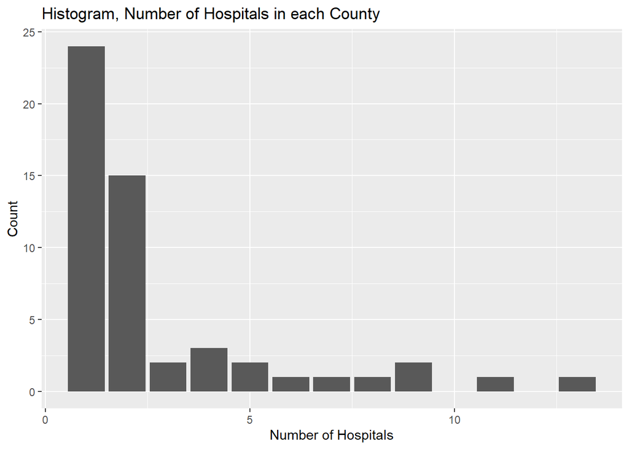

One obstacle to drawing conclusions by location of the hospital is the majority of counties only include one or two hospitals offering perinatal services. One way to avoid this is to recode the dataset to include the 10 established regions of New York State. This will also remove the ‘rest of state’ and ‘Statewide’ statistics from the dataset as previously omitted.

### Region

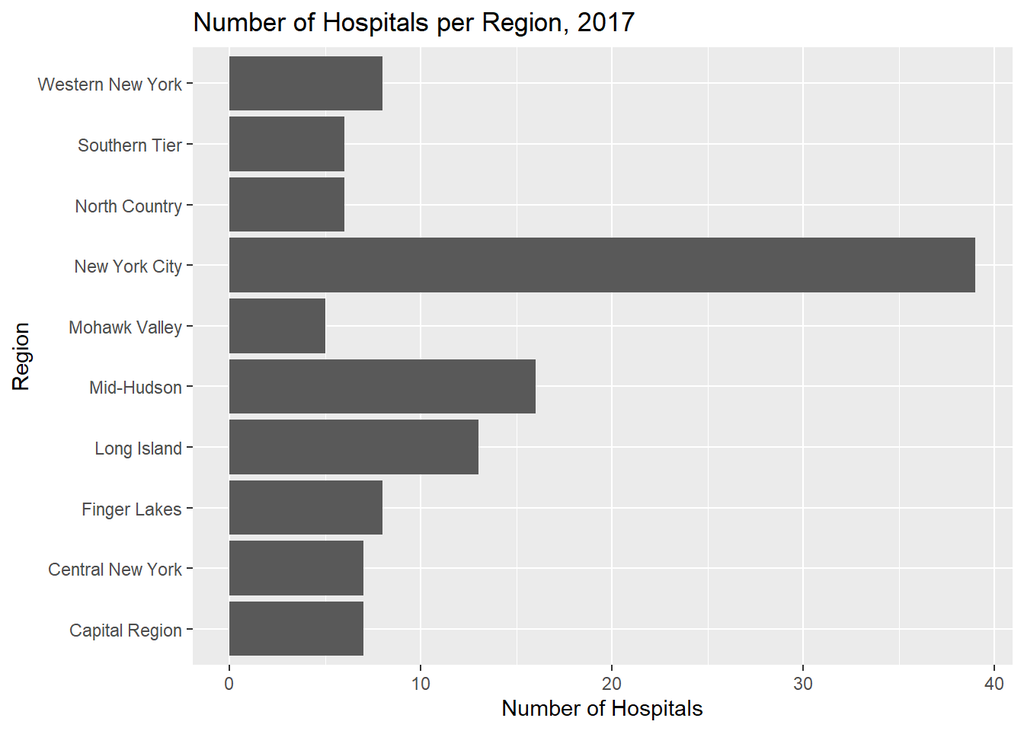

### New York City Borough

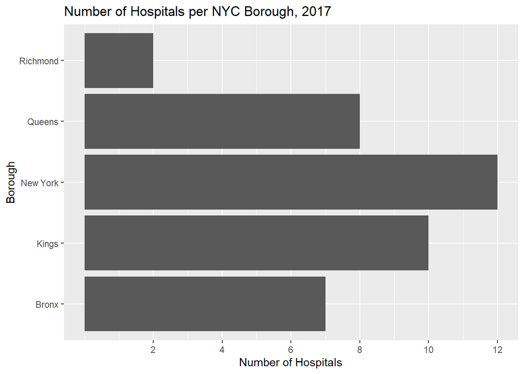

Grouping by region offers a larger pool of hospitals to compare, although New York City is a clear outlier for the number of hospitals. Looking only at each NYC borough offers the insight that hospitals in the city are distributed between the five boroughs, although Staten Island is a clear minimum.

## Birth Measures

### Where are Babies Being Born?

The immediate question for many is where are New York State’s babies being born? To answer this question initially, I’ll look at the raw totals, without consideration of existing population in the region.

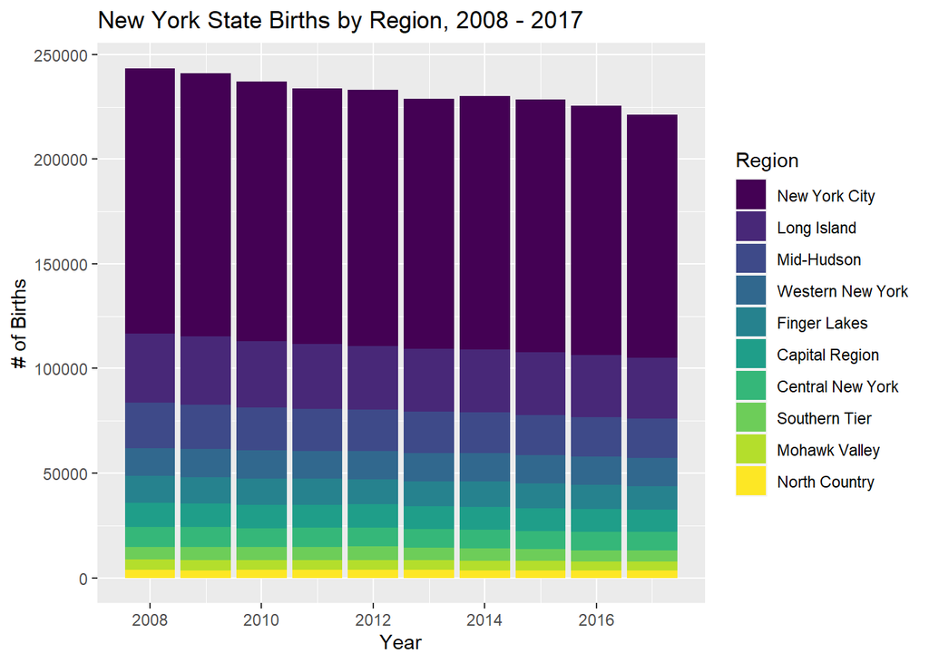

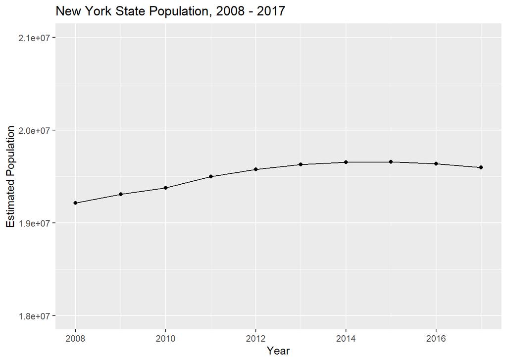

It appears that total population growth has also decreased during this period, with state population supposedly reaching its maximum in 2015. Next, let’s use these estimates to get the per capital birth rate.

#### Birth Rate by Region

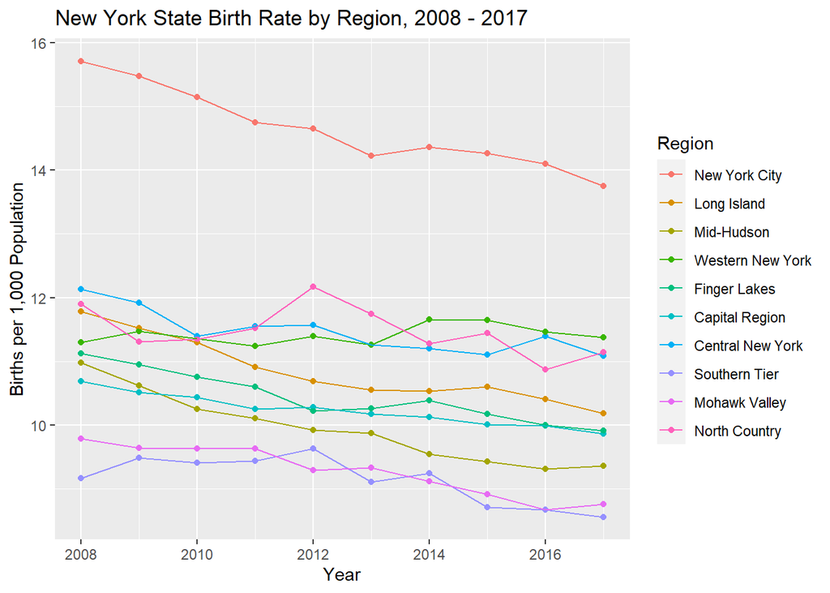

After considering the underlying population of each region, New York City remains the area with the largest birth rate, while the lowest population regions had some of the lowest birth rates. The one surprising result is the North Country region having a middle of the pack birth rate.The reason for this is not obvious, although geographically this region is very large with low population density and likely has plenty of room for population growth. Another theory worth considering is availability of non-hospital birthing options. Rural areas tend to attract fewer medical professional like obstetrician-gynecologists (OB/GYN’s), so it’s a drawback of these data that out-of-hospital births are not estimated. We will look in the next section at the presence of mid-level practitioners in these areas.

Also notable is stagnant or decreasing birth rates across the whole state. This treatment of the data supports the conclusion that babies are being born where the most people live, namely New York City. Also from our understanding of the number of hospitals, this area has some of the highest density of facilities and may attract families from other regions for advanced care or induced births.

### Childbirth and Midwives

Midwives are specialized healthcare professionals whose scope of practice includes prenatal and perinatal care. They are able to practice independently while overseeing low-risk pregnancies and more complicated presentations like breech births, but can also collaboratively with obstetricians and nurses to assisted in complex births. This is a relevant statistic when choosing a hospital because it may determine which healthcare professional will be overseeing a delivery. Families may prefer to work with a midwife versus another mid-level practitioner or medical doctor based on their preferred type of care. The rise of midwifery as an alternative to OB/GYN doctors may also indicate greater scarcity of doctors offering perinatal care relative to demand, as midwives require fewer years of training.

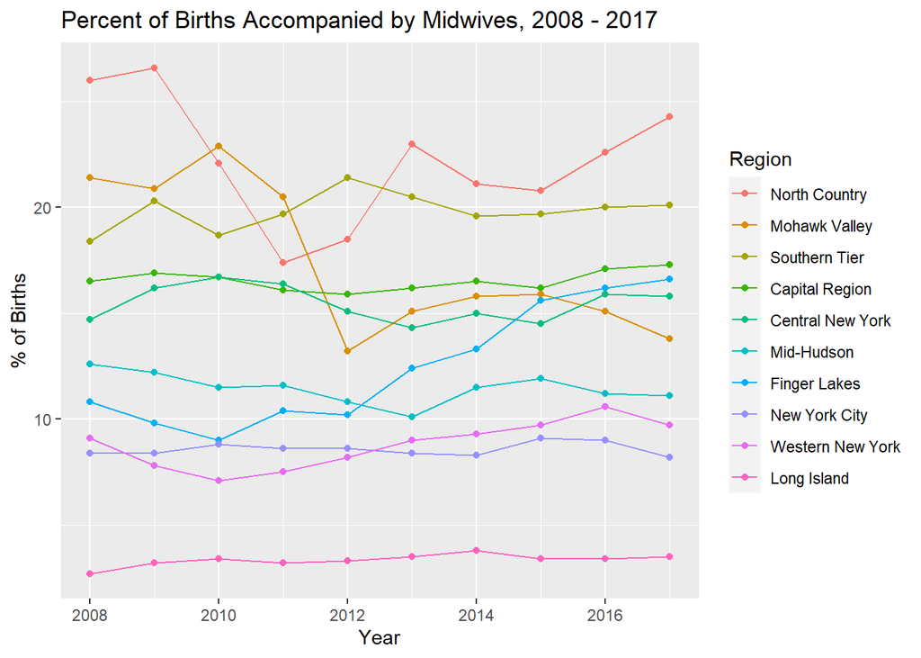

### Cesarian Births

Another piece of conventional wisdom to examine is the rise of Cesarean births or so-called C-sections. C-sections are the alternative to vaginal deliveries and are performed by accessing the uterus through an incision in the mother’s uterus, while under general or local anesthesia. There are a variety of reasons why C-sections would be necessary depending on the orientation of the child or obstruction in the birth canal, multiple pregnancies to be delivered, or emergency situations. C-sections are also done upon request, with the trade-off of shorter induction period versus longer recovery period.

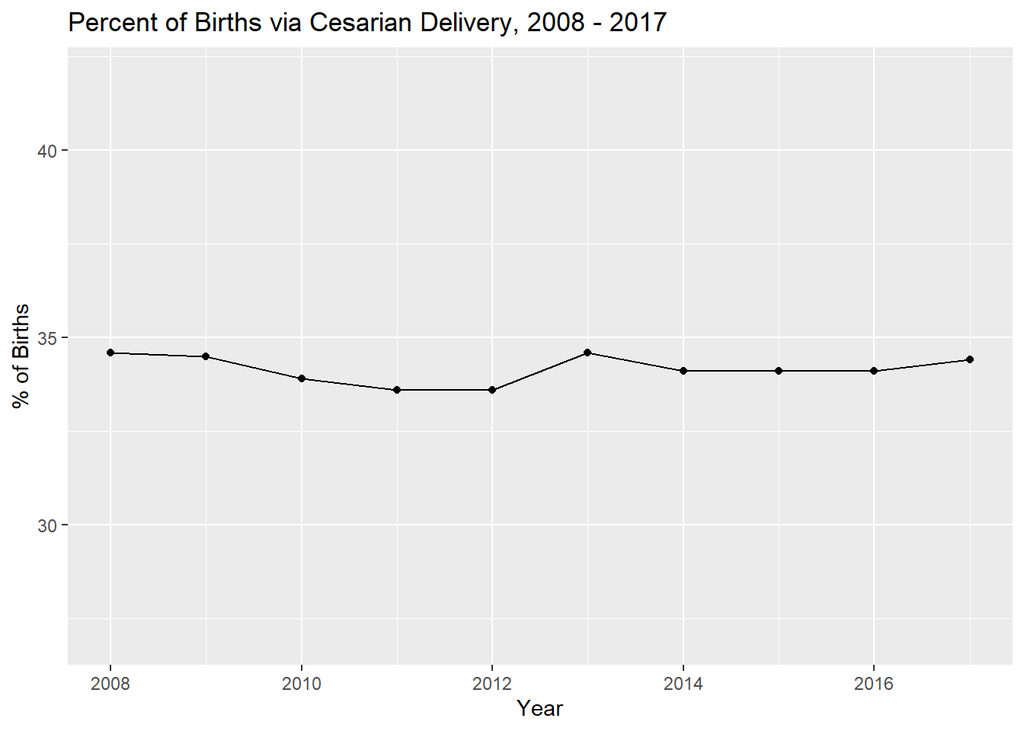

During this period of time, there’s no indication that the proportion of Cesarean births increased.

## Perinatal Center Designation

In addition to state-level concerns, identification of a birthing center and perinatal care is also a nationwide concern. The American Academy of Pediatrics and American College of Obstetricians and Gynecologists outline a regional organization of perinatal care, with four levels of intensifying facility care. A level 1 facility provides care for the lowest risk births, while levels 2,3, and regional centers offer greater support services during childbirth, as well as operate neonatal intensive care units (NICUs). Perinatal care has also entered the public sphere as a handful of celebrities have reported complications during childbirth, as well as efforts to document maternal harm in ProPublica’s *Lost* *Mothers* series.

The dataframe available for NY state also gives the exact location via latitude and longitude for each hospital, as well as the unique identifier that each licensed healthcare facility in New York has.

### Birthing Centers by Region

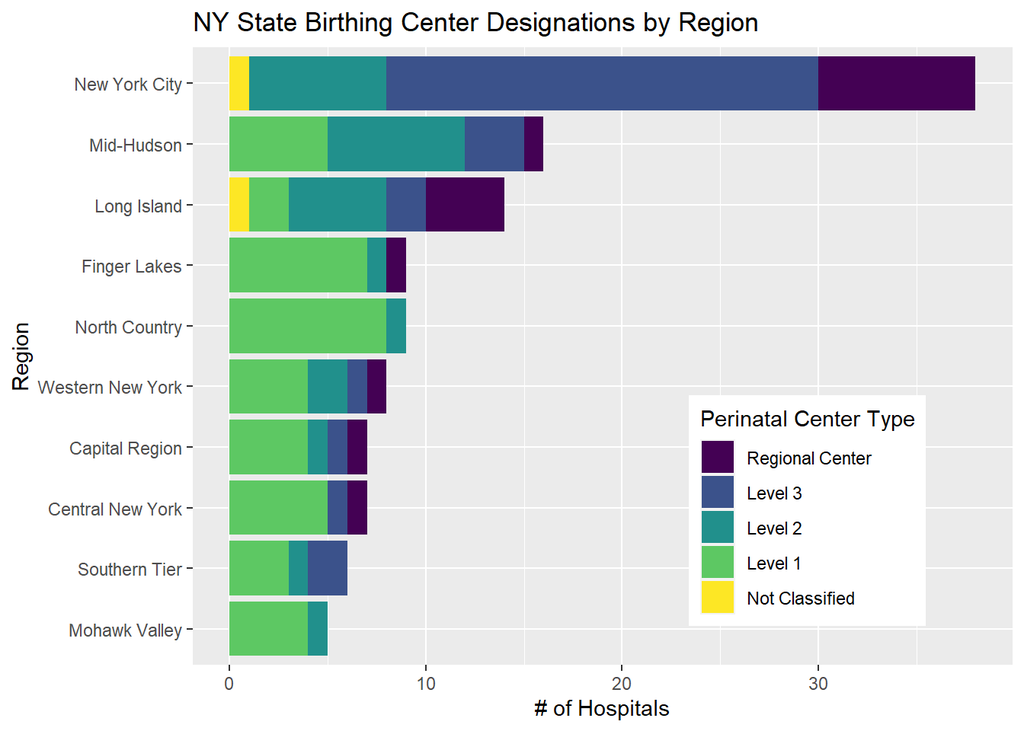

Once again, New York City is the clear outlier when it comes to perinatal center designation. It has no Level 1 centers, only the three higher designations. For the rest of New York, there’s a general pattern that Level 1 centers serve as a base and there’s at least one higher level center for more complex pregnancies or intensification of treatment.

### Perinatal Centers versus Birth Rates

Next, let’s consider the capacity of each of these hospitals: are regional centers also delivering more babies, or are the hospital beds reserved for only for the cases that demand it?

To proceed, there’s one issue I’ll have to address with the perinatal center data, which is that some of the hospitals in our initial dataset are not listed as birthing centers. I’ll identify these centers, see if they are significant contributors to the number of births, and then join the two.

In all, there are 3 facilities missing from the original dataframe, and 20 from the perinatal center dataframe. For the three missing from the original, the Burdett Center was consolidated into the Samaritan Hospital in Troy, NY, and the remaing two are smaller hospitals in Saint Lawrence county. I have since updated the ID for the Burdett Center.

#### Unclassified Hospitals

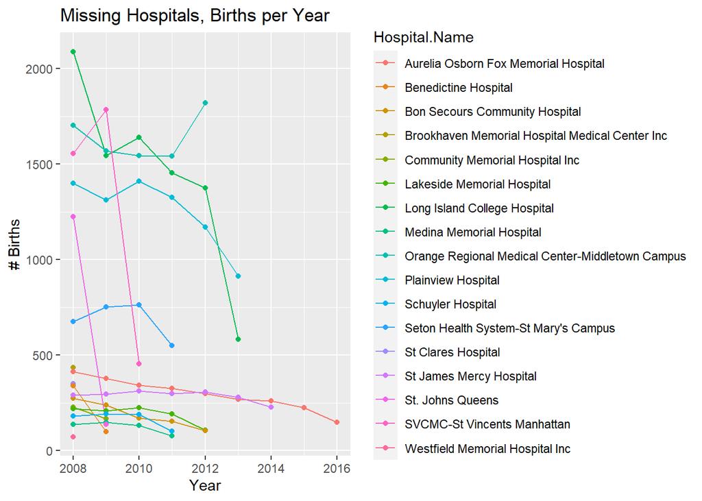

On the other hand, there are 20 hospitals missing as perinatal care centers. Some of these I will omit as they no longer report data at the end of the study period in 2017. This could be because of closure or consolidation with another nearby hospital. For the remaining hospitals, Beth Israel and Mercy Medical Center, I manually added these to the second dataframe for later use. I did not specify what level of care they both are, although both facilities contain NICU’s and would likely be at least Level 2.

### Annual Births by Center Type

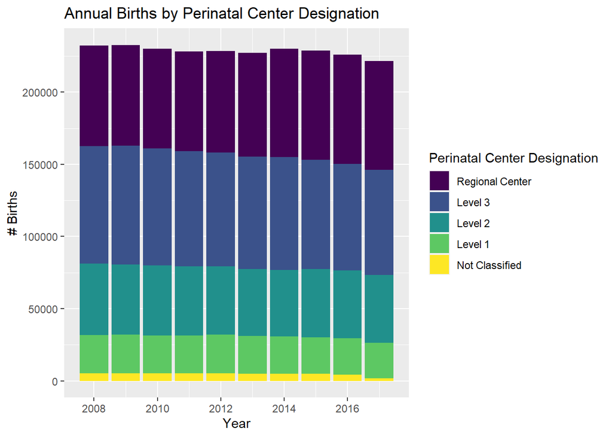

Interestingly, some of the most advanced care centers are also the ones that are delivering the most babies. This may very well be their profit model - plan to perform many deliveries and be prepared to escalate care seamlessly if the situation warrants it. This also may be an artifact of the urban-rural divide when it comes to perinatal care centers, which I’ll visualize geographically in the final section.

## Birth Defects

After reviewing the publicly available datasets, I ended up incidences of birth defects for the state as an indicator of complex pregnancy or untoward effects during delivery. This dataset offered a lot more detail that I needed for the assignment, with dozens of columns specifying different types of malformations or congenital effects that manifest after delivery. Instead, I’ll be looking at the sum total of birth defects for each county. Because birth defects are rare, this dataset also reports in 3-year groups, e.g., 2009 - 2011, 2012 - 2014. For future comparisons, I’ll be comparing birth and populations rates for these years only.

### Birth Defects by Region

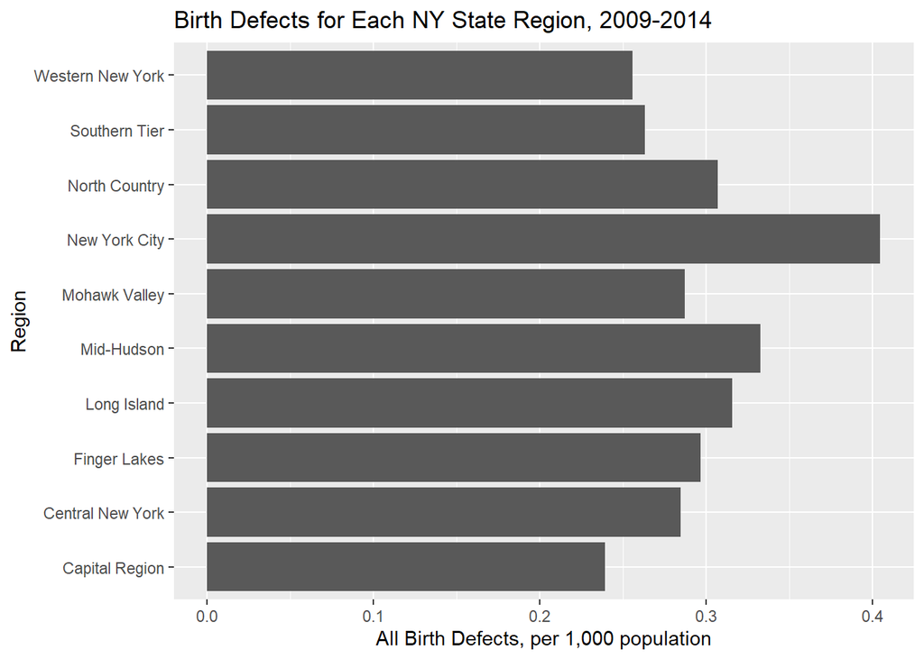

Looking first at region, each region generally reports between 0.2 and 0.4 birth defects per 1,000 population.

### Regional Birth Rate versus Defects

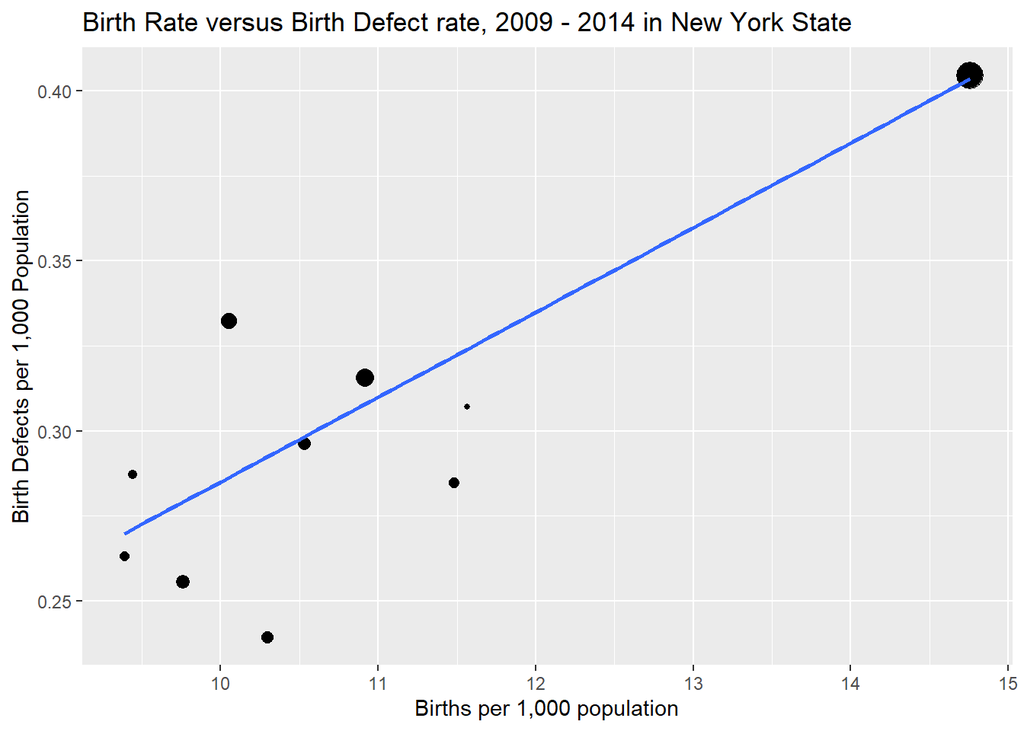

This first scatterplot compares the regional per capita birth and defect rates. The size of the point indicates the region’s population, and the trendline is weighted to population as well. The positive trend is likely the effect of the New York City region reinforcing a pattern that doesn’t hold up once it’s omitted. To get a more detailed look, I’ll consider county statistics next.

### County Birth Rate versus Defects

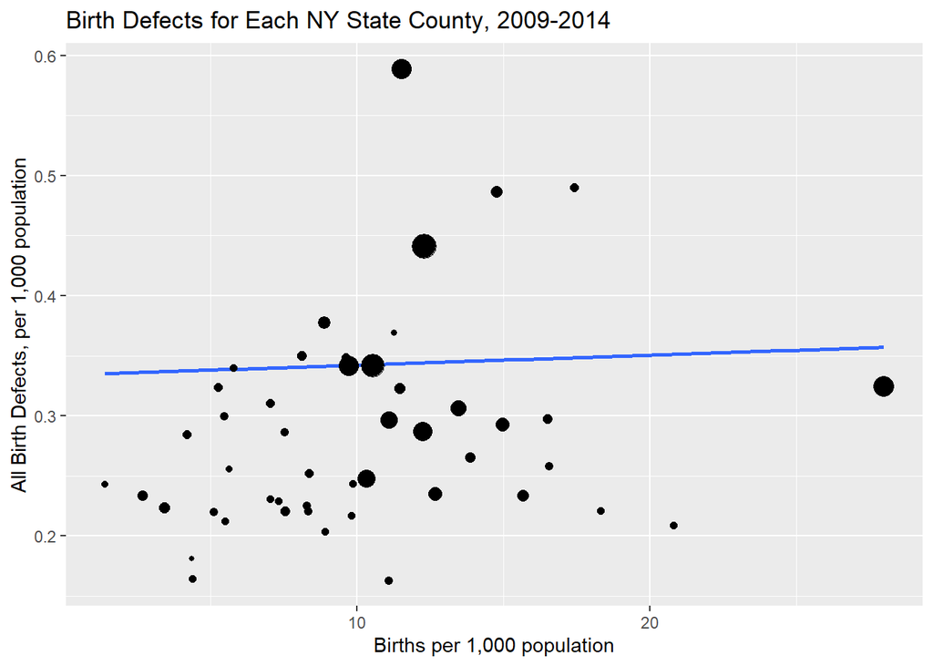

### Hospitals, Perinatal Centers, and Birth Defects

Tying everything all together, the last visualization will finally consider the same space as regional and county births versus birth defects, except the final implementation will consider each individual hospital. This will hopefully add even more detail than the geographical distinctions.

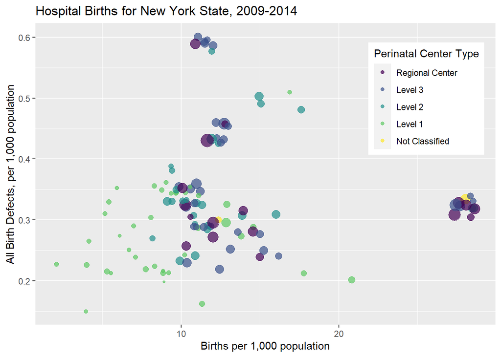

For the final graph of this project, I decided to build on all of the datasets I’ve used so far. Similar to the counties and regions graphs before them, I’m interested in where the data falls on a plane comparing birth rate with the birth defect rate. Like before, any trend would be notable for suggesting a causal relationship. Some birth defects, like physical abnormalities, may be difficult to detect in the prenatal period. One of the potential confounders – more complex births leading to greater defects – could potentially be controlled by looking at the care level at the time of birth. So in addition to looking at the clusters around county data, I will also separate each county into its respective hospitals, and further distinguish by number of births and perinatal care level.

## Maps

Finally, let’s visualize hospitals and births relative to the geography of New York State.

To reinforce the urban versus rural divide, consider where the hospitals fall geographically. The greater metro area contains the majority of large, advanced perinatal care centers. Meanwhile, smaller community hospitals are dotted along the many other counties of New York State. Some of the only exceptions are the major metro areas outside of New York City, namely Rochester and Buffalo.

### Hospital Locations

[interactive chart not shown]

### Map: Birth Defects vs. Birth Rate

[interactive chart not shown]

In the above, red saturation means increasing birth rates and blue saturation means increasing defect rates. The purple colors indicate a mix of both rates. So in saturated blue and purple counties there are an excess of birth defects relative to the state’s average birth rate. In cases where the birth rate is low and defects remain high (dark blue), this could indicate higher-risk pregnancies or environmental effects are contributing to the increased incidence. Meanwhile, deep purple indicates high births and high defect incidence, meaning that these counties could benefit from greater resources as their outcomes could improve with increased capacity. The deep red states are overperformers, with better outcomes despite high birth rates.

## Consumer-Facing Portal

I have also developed a patient-facing portal for comparing statistics and performance over time within their region. It is a shiny app available at https://thomas-hill.shinyapps.io/NYS_hospital_maternity_information/

## Conclusions and Future Directions

This was a survey of the many demands and outcomes related to one specific type of medical care. Though professional groups and media accounts espouse a single perspective on perinatal care, not all perinatal care is the same and requires some research into local institutions. The majority of births still happen at hospitals under a doctor’s care, but a surface look indicates that there’s variation in the services provided at the hospital, motivated by supply and demand. While there’s a burgeoning movement to improve outcomes related to perinatal care, my findings support that some places face unique barriers according to the population they serve.

In the future, more work could be done looking at rates of particular birth defects, as well as outcomes data from public sources like HCAHPS (Hospital Consumer Assessment of Healthcare Providers and Systems). My findings could also be replicated in many other states and metro areas, as ACOG recommendations have a national audience. Finally, some validation work could be done to improve New York statistics, such as accounting for alternative or out-of-hospital births, as well as out-of-state or border state cases.

### Sources, Datsets, and additional Reading

Sources: New York State Public Health Law: § 2803-j, Information for Maternity Patients: https://www.health.ny.gov/facilities/hospital/maternity/public_health_law_section_2803-j.htm

Perinatal level centers in New York: https://profiles.health.ny.gov/Hospital/designated_center/Level+3+Perinatal+Center

Guidelines for Perinatal Care, 8th Edition: https://www.acog.org/clinical-information/physician-faqs/-/media/3a22e153b67446a6b31fb051e469187c.ashx

Datasets:

Maternity statistics: https://health.data.ny.gov/Health/Hospital-Maternity-Information-Beginning-2008/net3-iygw

Birth Defect Prevalence: https://health.data.ny.gov/Health/Birth-Defect-Prevalence-Beginning-1992/mz8x-255x

New York Population Estimates: https://data.ny.gov/Government-Finance/Annual-Population-Estimates-for-New-York-State-and/krt9-ym2k

More reading: Federal Officials Aim to Cut Maternal Deaths by Half: https://www.usnews.com/news/health-news/articles/2020-12-03/federal-officials-aim-to-reduce-maternal-deaths-by-50

New York State Maternal and Child Health Dashboard:https://webbi1.health.ny.gov/SASStoredProcess/guest?_program=/EBI/PHIG/apps/mch_dashboard/mch_dashboard&p=ct